```
                                                                            ##  Sondra, Franck, Marceline
```

# Projet 2 - Médiathèque

## Présentation du sujet

### Motivation et objectif global

Projet : Objectif

Cas réel d’entreprise :

=> Mise en œuvre d’une banque de données de films.

A partir d’une expression de besoin plus ou moins complète, réaliser les analyses nécessaire permettant de modéliser les données, d’implémenter la base de données correspondante et d’effectuer les manipulations cohérentes des données.

#### Etapes & Compétences associées (cf. référentiel de certification)

- Expression de besoin fournie C8. Analyser et formaliser la demande
- Modéliser les données C1. Concevoir et structurer physiquement une BDD
- Implémenter la base de données C1. Concevoir et structurer physiquement une BDD
- Manipuler les données de la base C3. Intégrer des données propres et préparées dans la BDD et/ou C5. Interroger la BDD et/ou C2. Acquérir les données
- Effectuer la maintenance de la base C4. Optimiser une BDD
- Développer une application web (ou autre applicatif) C6. Concevoir et réaliser un rendu visuel des données (dataviz + appli)

## Expression de besoin fournie

### Les Besoins de L'Utilisateur

Un référentiel de films disponibles à la médiathèque.

Ce référentiel serait mis à disposition des clients pour recherche de film en fonction du titre, du réalisateur, du studio de production.

Afin d’aider au mieux les clients dans leurs choix, le patron souhaite organiser les films par catégorie et par langue.

Le patron souhaite également présenter des informations concernant les acteurs, les studios et les remake de films.

Les clients de la médiathèque doivent pouvoir effectuer une recherche de film sur 2 ou 3 critères, via une interface web.

### Les limites du sujet

Le sujet est bien large, il a donc des limites dans l’élaboration de la base de données, qui offert le location de film, ne inclus pas le parti de

1. paiement actuel.
2. la disponibilité de chaque film également indiquée.
3. donnant accès à l'emprunt ou au alternatif au cas échéant.

### Description des contraintes

```python
 - MySQL
 - PHPMySQL
 - Python
 - Spyder
 - Dash
```

## Réponses aux attentes de l’Utilisateur

### Consultation des données

Client :

```
Base de données au sein d’une médiathèque
```

Ses Clients :

```
Souhaite disposer d’un référentiel de films disponibles à la médiathèque.

Recherche de film en fonction du titre, du réalisateur, du studio de production.

Organiser les films par catégorie et par langue.

Présenter des informations concernant les acteurs, les studios et les remake de films.

Effectuer une recherche de film sur 2 ou 3 critères, via une interface web.
```

### Mise à jour des données

à determiner

## Livrable final : Produit utilisable + Démo

### Premier determination

#### MCD

[figure not shown]

#### MPD

[figure not shown]

#### Dictionnaire

[figure not shown]

#### API

- Accès par nom d’utilisateur et mot de passe.
- Recherche un film par nom, acteur, producteur, rélisateur, studio, année et catégorie.
- Proposition d’une table avec les résultat de la requête.
- Réduire ou augmenter les films disponibles par requëte.

[figure not shown]

# BDD & Tables

## Déterminer la création de tables en SQL.

```python
SET SQL_MODE = "NO_AUTO_VALUE_ON_ZERO";
SET time_zone = "+00:00";


/*!40101 SET @OLD_CHARACTER_SET_CLIENT=@@CHARACTER_SET_CLIENT */;
/*!40101 SET @OLD_CHARACTER_SET_RESULTS=@@CHARACTER_SET_RESULTS */;
/*!40101 SET @OLD_COLLATION_CONNECTION=@@COLLATION_CONNECTION */;
/*!40101 SET NAMES utf8mb4 */;

--
-- Base de données :  `BDD_Médiathèque`
--
CREATE DATABASE IF NOT EXISTS `BDD_NomMédiathèque` DEFAULT CHARACTER SET latin1 COLLATE latin1_swedish_ci;
USE `BDD_NomMédiathèque`;
```

```python
-- --------------------------------------------------------

--
-- Structure de la table `FILMS`
--

DROP TABLE IF EXISTS `FILMS`;
CREATE TABLE `FILMS` (
  `FilmRef` varchar(10) COLLATE utf8_bin NOT NULL,
  `Film_Nom` varchar(60) COLLATE utf8_bin NOT NULL,
  `Film_Ann` int(4) DEFAULT NULL,
  `FR_nom` varchar(50) COLLATE utf8_bin DEFAULT NULL,
  `FP_nom` varchar(50) COLLATE utf8_bin DEFAULT NULL,
  `FS_nom` varchar(50) COLLATE utf8_bin DEFAULT NULL,
  `Categorie` varchar(10) COLLATE utf8_bin DEFAULT NULL
) ENGINE=InnoDB DEFAULT CHARSET=utf8 COLLATE=utf8_bin;

--
-- Contenu de la table `FILMS`
--

INSERT INTO `FILMS` (`FilmRef`, `Film_Nom`, `Film_Ann`, `FR_nom`, `FP_nom`, `FS_nom`, `Categorie`) VALUES
('AA1', 'Shooting Stars', 1928, 'Asquith', NULL, NULL, NULL),
('AA13', 'Pygmalion', 1938, 'Asquith', 'G.Pascal', NULL, NULL),
```

```python
-- --------------------------------------------------------

--
-- Structure de la table `People`
--

DROP TABLE IF EXISTS `People`;
CREATE TABLE `People` (
  `ref` varchar(50) COLLATE utf8_bin NOT NULL,
  `first` varchar(45) COLLATE utf8_bin DEFAULT NULL,
  `last` varchar(45) COLLATE utf8_bin DEFAULT NULL,
  `codes` varchar(10) COLLATE utf8_bin DEFAULT NULL
) ENGINE=InnoDB DEFAULT CHARSET=utf8 COLLATE=utf8_bin;

--
-- Contenu de la table `People`
--

INSERT INTO `People` (`ref`, `first`, `last`, `codes`) VALUES
('A.Bennett', 'Alan', 'Bennett', 'WD'),
('A.Bergman', 'Andrew', 'Bergman', 'WD'),
```

```python
-- --------------------------------------------------------

--
-- Structure de la table `REMAKES`
--

DROP TABLE IF EXISTS `REMAKES`;
CREATE TABLE `REMAKES` (
  `RemakeID` varchar(40) COLLATE utf8_bin NOT NULL,
  `OrigID` varchar(40) COLLATE utf8_bin NOT NULL
) ENGINE=InnoDB DEFAULT CHARSET=utf8 COLLATE=utf8_bin;

--
-- Contenu de la table `REMAKES`
--

INSERT INTO `REMAKES` (`RemakeID`, `OrigID`) VALUES
('AA13', 'LuB20'),
('AA13', 'HH15'),
```

```python
#Constraint fails because of the duplication in reference ...soient examinées----------------
#ALTER TABLE REMAKES
#  ADD CONSTRAINT FK_FILMS_FilmRef FOREIGN KEY (FilmRef)
#      REFERENCES FILMS (FilmRef)
#      ON DELETE CASCADE
#      ON UPDATE CASCADE
#  ;
#----------------------------------------------------------------------------------------------------------
```

```python
-- --------------------------------------------------------

--
-- Structure de la table `ACTEURS`
--

DROP TABLE IF EXISTS `ACTEURS`;
CREATE TABLE `ACTEURS` (
  `ActeurID` int(11) NOT NULL,
  `Acteurs` varchar(60) COLLATE utf8_bin DEFAULT NULL,
  `Act_CDB` int(4) DEFAULT NULL,
  `Act_CDF` int(4) DEFAULT NULL,
  `Act_Prenoms` varchar(45) COLLATE utf8_bin DEFAULT NULL,
  `Act_Noms` varchar(45) COLLATE utf8_bin DEFAULT NULL,
  `Act_Sx` varchar(5) COLLATE utf8_bin DEFAULT NULL,
  `Act_DDN` varchar(45) COLLATE utf8_bin DEFAULT NULL,
  `Act_DDD` varchar(45) COLLATE utf8_bin DEFAULT NULL,
  `Act_Prf` varchar(60) COLLATE utf8_bin DEFAULT NULL,
  `Act_Orig` varchar(20) COLLATE utf8_bin DEFAULT NULL
) ENGINE=InnoDB DEFAULT CHARSET=utf8 COLLATE=utf8_bin;

--
-- Contenu de la table `ACTEURS`
--

INSERT INTO `ACTEURS` (`ActeurID`, `Acteurs`, `Act_CDB`, `Act_CDF`, `Act_Prenoms`, `Act_Noms`, `Act_Sx`, `Act_DDN`, `Act_DDD`, `Act_Prf`, `Act_Orig`) VALUES
(100001, 'Willie Aames', NULL, NULL, 'William', 'Aames', 'M', '1960', '199x', 'RU:', 'Am'),
(100002, 'Diahnne Abbott', 1976, 1982, 'Diahnne', 'Abbott', 'F', '1945', '199x', 'R:sexy', 'Am'),
```

```python
-- --------------------------------------------------------

--
-- Structure de la table `CASTS`
--

DROP TABLE IF EXISTS `CASTS`;
CREATE TABLE `CASTS` (
  `Film_Ref` varchar(10) COLLATE utf8_bin NOT NULL,
  `Film_Nom` varchar(100) COLLATE utf8_bin NOT NULL,
  `Acteurs` varchar(50) COLLATE utf8_bin DEFAULT NULL,
  `Pers` varchar(50) COLLATE utf8_bin DEFAULT NULL,
  `Role` varchar(200) COLLATE utf8_bin DEFAULT NULL
) ENGINE=InnoDB DEFAULT CHARSET=utf8 COLLATE=utf8_bin;

--
-- Contenu de la table `CASTS`
--

INSERT INTO `CASTS` (`Film_Ref`, `Film_Nom`, `Acteurs`, `Pers`, `Role`) VALUES
('AA13', 'Pygmalion', 'Leslie Howard', 'Sci', NULL),
('AA13', 'Pygmalion', 'Wendy Hiller', 'Inn', NULL),
```

```python
-- --------------------------------------------------------

--
-- Structure de la table `CLIENTS`
--

DROP TABLE IF EXISTS `CLIENTS`;
CREATE TABLE `CLIENTS` (
  `ClientID` int(11) NOT NULL,
  `Cl_Nom` varchar(50) COLLATE utf8_bin NOT NULL,
  `Cl_Pren` varchar(50) COLLATE utf8_bin NOT NULL,
  `Cl_Sx` char(1) COLLATE utf8_bin NOT NULL,
  `Cl_DDN` date NOT NULL,
  `Cl_Tel` varchar(14) COLLATE utf8_bin DEFAULT NULL,
  `Cl_Em` varchar(50) COLLATE utf8_bin NOT NULL,
  `Cl_Prf` varchar(50) COLLATE utf8_bin DEFAULT NULL,
  `Cl_Fav` varchar(50) COLLATE utf8_bin DEFAULT NULL,
  `Cl_EC` varchar(5) COLLATE utf8_bin DEFAULT NULL,
  `Cl_Mbr` varchar(15) COLLATE utf8_bin DEFAULT NULL,
  `Cl_Date` date DEFAULT NULL
) ENGINE=InnoDB DEFAULT CHARSET=utf8 COLLATE=utf8_bin;

--
-- Déclencheurs `CLIENTS`
--
DELIMITER //
CREATE TRIGGER check_sex AFTER INSERT ON CLIENTS FOR EACH ROW BEGIN
IF CLIENTS.Cl_Sx COLLATE utf8_bin NOT IN ('M','F','O') AND CLIENTS.Cl_Sx IS NOT NULL THEN
    SIGNAL SQLSTATE '22222' SET MESSAGE_TEXT='Le sexe doit être''M'' ou ''F'' ou ''O'' ou NULL';
    END IF;
END//
```

```python
-- --------------------------------------------------------

--
-- Structure de la table `LOCATION`
--

DROP TABLE IF EXISTS `LOCATION`;
CREATE TABLE `LOCATION` (
  `LocationID` int(11) NOT NULL,
  `Loc_DB` date DEFAULT NULL,
  `Loc_DF` date DEFAULT NULL,
  `Client` int(11) NOT NULL,
  `Film` int(11) NOT NULL,
  `Mod_Pay` varchar(15) COLLATE utf8_bin NOT NULL
) ENGINE=InnoDB DEFAULT CHARSET=utf8 COLLATE=utf8_bin;
```

## Modifications des csv & données par Python avant de mettre sur PHPMySQL

### Nettoyage en OpenRefine

Fait

1. J’ai enlevé toutes les marques ("", ?, ), etc. )
2. Modification des abréviations des catégories en mots complets
3. Suppression des doublons
4. Modifier le format des colonnes de l’année en nombre - value.toNumber()
5. Modifier les colonnes NOM dans le cas Titre - value.toTitlecase()
6. Valeurs NULL - vérifiées ou supprimées dans les colonnes
7. Enlevez whitespaces
8. Corriger l'orthographe
9. Diviser les colonnes en deux colonnes ou plus (e.g. 1978-1998 -> 1978 | 1998)

Non fait

1. Supprimer le D:, P:, St, etc. (ex. St: nom de studio dans le table STUDIO, SN: nom de studio pas dans le table STUDIO)

### Preparation de table d'Acteurs

```python
import pandas as pd

#Ajoute index à Acteurs
df = pd.read_csv("/home/perrot/Bureau/TEST/TESTTEMP/ACTEURS_orig.csv", encoding = 'utf8', sep=',')
df.insert(0, 'Acteur_ID', range(100001, 100001 + len(df)))

#Set Index à Acteur_ID column
df.set_index("Acteur_ID", inplace = True)

print(df.head())

#Save to CSV file
#df.to_csv('/home/perrot/Bureau/TEST/ACTEURS.csv')
```

[figure not shown]

### Merge CASTS et ACTEURS

Cela ne génère pas de données précises car il ya des noms d'acteurs en double et donc le résultat peut être faux.

Read casts & acteur csv - NOTE: Quelque fois il y a un erreur, il faut de faire exécuter dans Spyder.

```python
#import pandas as pd

Casts=pd.read_csv("/home/perrot/Bureau/TEST/CASTS.csv", encoding = 'utf8', sep=',')
Casts.columns=["Acteurs"]
Acteurs=pd.read_csv("/home/perrot/Bureau/TEST/ACTEURS.csv", encoding = 'utf8', sep=',')
Acteurs.columns=["Acteurs"]

#Merge casts & actors
CAmerge=pd.merge(Casts, Acteurs, on='Acteurs', how='inner')
print(CAmerge.head())
#Save to CSV file
CAmerge.to_csv('/home/perrot/Bureau/Projet2_WIP/CSV/FILMACT.csv', sep=',', columns=['Film_Ref', 'Acteur_ID'], index=False, header=True, mode='w', encoding=None)
```

### Remplacer REMAKES.CSV (table de jointure)

```python
import pandas as pd

REMAKEJ=pd.read_csv("/home/perrot/Bureau/TEST/TESTTEMP/REMAKES.csv", encoding = 'utf8', sep=',')
REMAKEJ.to_csv('/home/perrot/Bureau/TEST/REMAKESJJ.csv', sep=',', columns=['RemakeID', 'OrigID'], index=False, header=True, mode='w', encoding=None)
```

## Executer Python3 - Tables et données

Créer une structure de table et mettre en ligne les données. Ajouter les producers en people.

```python
#Connecté avec le serveur ....ssh -X -L3306:localhost:3306 -L5432:localhost:5432 $USER@datalab.myconnectech.fr
```

```python
# -*- coding: utf-8 -*-

#~ https://github.com/cernoch/movies.git

# executer avec :
#> python3 P2_CSV2SQLSP.py --base /home/perrot/Bureau/TEST --bdd BDD_Sondra?charset=utf8

import pandas as pd
import numpy as np
from sqlalchemy import create_engine
import argparse
#~ import creds
import os,configparser # credentials:

parser = argparse.ArgumentParser()
#~ parser.add_argument("-f", action="store_true", help="traite FILMS")
#~ parser.add_argument("-p", action="store_true", help="traite People")
parser.add_argument("-v", action="store_true", help="Verbose SQL")
parser.add_argument("--base", help="Répertoire de movies")
parser.add_argument("--bdd", help="Base de donnée")
args = parser.parse_args()

config = configparser.ConfigParser()
config.read_file(open(os.path.expanduser("~/.datalab.cnf")))
print(config.sections())

base = args.base #"/home/perrot/Bureau/TEST"

DB=args.bdd #'BDD_Sondra?charset=utf8' # mySQL...
mySQLengine = create_engine("mysql://%s:%s@%s/%s" % (config['myBDD']['user'], config['myBDD']['password'], config['myBDD']['host'], DB), echo=args.v)

# Suppression des tables (dans le bon ordre)
# Vidage des tables : Film et People
mySQLengine.execute("DROP TABLE IF EXISTS FILMS ;")
mySQLengine.execute("SET FOREIGN_KEY_CHECKS = 0;");
mySQLengine.execute("DROP TABLE IF EXISTS People ;")
mySQLengine.execute("SET FOREIGN_KEY_CHECKS = 1;");
mySQLengine.execute("DROP TABLE IF EXISTS REMAKES ;")
mySQLengine.execute("SET FOREIGN_KEY_CHECKS = 1;");
mySQLengine.execute("DROP TABLE IF EXISTS CASTS ;")
mySQLengine.execute("SET FOREIGN_KEY_CHECKS = 1;");
mySQLengine.execute("DROP TABLE IF EXISTS ACTEURS ;")
mySQLengine.execute("SET FOREIGN_KEY_CHECKS = 1;");
mySQLengine.execute("DROP TABLE IF EXISTS CLIENTS ;")
mySQLengine.execute("SET FOREIGN_KEY_CHECKS = 1;");
mySQLengine.execute("DROP TABLE IF EXISTS LOCATION ;")
mySQLengine.execute("SET FOREIGN_KEY_CHECKS = 1;");

# Création, avec script. Un lien externe Film.producer -> People.ref
mySQLengine.execute("""
CREATE TABLE IF NOT EXISTS `BDD_Sondra`.`People` (
  `ref` VARCHAR(50) NOT NULL,
  `first` VARCHAR(45) NULL,
  `last` VARCHAR(45) NULL,
  `codes` VARCHAR(10) NULL,
  PRIMARY KEY (`ref`))
ENGINE = InnoDB
DEFAULT CHARACTER SET = utf8
COLLATE = utf8_bin;
""")

mySQLengine.execute("""
CREATE TABLE IF NOT EXISTS `BDD_Sondra`.`FILMS` (
   FilmRef VARCHAR(10) NOT NULL,
   Film_Nom VARCHAR(60) NOT NULL,
   Film_Ann INT(4) NULL,
   FR_nom VARCHAR(50) NULL,
   FP_nom VARCHAR(50) NULL,
   FS_nom VARCHAR(50) NULL,
   Categorie VARCHAR(10) NULL,
  PRIMARY KEY (`FilmRef`),
  UNIQUE INDEX `FilmRef_UNIQUE` (`FilmRef` ASC))
ENGINE = InnoDB
DEFAULT CHARACTER SET = utf8
COLLATE = utf8_bin;
""")

mySQLengine.execute("""
CREATE TABLE IF NOT EXISTS `BDD_Sondra`.`REMAKES` (
    RemakeID VARCHAR(40) NOT NULL,
    OrigID VARCHAR(40) NOT NULL)
ENGINE = InnoDB
DEFAULT CHARACTER SET = utf8
COLLATE = utf8_bin;
""")

mySQLengine.execute("""
CREATE TABLE IF NOT EXISTS `BDD_Sondra`.`ACTEURS` (
    ActeurID INT NOT NULL AUTO_INCREMENT,
    Acteurs VARCHAR(60) NULL,
    Act_CDB INT(4) NULL,
    Act_CDF INT(4) NULL,
    Act_Prenoms VARCHAR(45) NULL,
    Act_Noms VARCHAR(45) NULL,
    Act_Sx VARCHAR(5) NULL,
    Act_DDN VARCHAR(45) NULL,
    Act_DDD VARCHAR(45) NULL,
    Act_Prf VARCHAR(60) NULL,
    Act_Orig VARCHAR(20) NULL,
    PRIMARY KEY (`ActeurID`))
ENGINE = InnoDB
DEFAULT CHARACTER SET = utf8
COLLATE = utf8_bin;
""")

mySQLengine.execute("""
CREATE TABLE IF NOT EXISTS `BDD_Sondra`.`CASTS` (
   Film_Ref VARCHAR(10) NOT NULL,
   Film_Nom VARCHAR(100) NOT NULL,
   Acteurs VARCHAR(50) NULL,
   Pers VARCHAR(50) NULL,
   Role VARCHAR(200) NULL)
ENGINE = InnoDB
DEFAULT CHARACTER SET = utf8
COLLATE = utf8_bin;
""")

mySQLengine.execute("""
CREATE TABLE IF NOT EXISTS `BDD_Sondra`.`CLIENTS` (
    ClientID INT NOT NULL AUTO_INCREMENT,
    Cl_Nom VARCHAR(50) NOT NULL,
    Cl_Pren VARCHAR(50) NOT NULL,
    Cl_Sx CHAR(1) NOT NULL,
    Cl_DDN DATE NOT NULL,
    Cl_Tel VARCHAR(14) DEFAULT NULL,
    Cl_Em VARCHAR (50) NOT NULL UNIQUE,
    Cl_Prf VARCHAR(50) DEFAULT NULL,
    Cl_Fav VARCHAR(50) DEFAULT NULL,
    Cl_EC VARCHAR(5) DEFAULT NULL,
    Cl_Mbr VARCHAR(15) DEFAULT NULL,
    Cl_Date DATE,
    PRIMARY KEY (`ClientID`))
ENGINE = InnoDB
DEFAULT CHARACTER SET = utf8
COLLATE = utf8_bin;
""")

mySQLengine.execute("""
CREATE TABLE IF NOT EXISTS `BDD_Sondra`.`LOCATION` (
   LocationID INT NOT NULL AUTO_INCREMENT,
   Loc_DB DATE DEFAULT NULL,
   Loc_DF DATE DEFAULT NULL,
   Client INT NOT NULL,
   Film INT NOT NULL,
   Mod_Pay VARCHAR(15) NOT NULL,
   PRIMARY KEY (`LocationID`))
ENGINE = InnoDB
DEFAULT CHARACTER SET = utf8
COLLATE = utf8_bin;
""")

# lecture CSV
peopleCSV = pd.read_csv(base+"/people.csv", encoding = 'utf8', sep=',', header=None)
peopleCSV.columns = ('Ref_name', 'codes', 'Did', 'years', 'last_n', 'first_n', 'dob', 'dod') # FROM HTML

# le même, avec les colonnes qui nous intéresse
people = peopleCSV[['Ref_name', 'first_n', 'last_n', 'codes']] # Selection column
people.columns = ('ref', 'first', 'last', 'codes') # Rename to SQL
people.drop_duplicates(subset='ref', keep='first', inplace=True) # Drop duplicate for UNIQUE
people.set_index('ref', inplace=True) # nouvel index

if (True): #(args.f):
    # Les films
    FILMSCSV = pd.read_csv(base+"/FILMS.csv", encoding = 'utf8', sep=',')
    FILMSCSV.columns = ('FilmRef','Film_Nom', 'Film_Ann', 'FR_nom', 'FP_nom', 'FS_nom', 'Process', 'Categorie', 'F_Rcp')
    # le même, avec les colonnes qui nous intéresse
    FILMS = FILMSCSV[['FilmRef','Film_Nom', 'Film_Ann', 'FR_nom', 'FP_nom']]

    # Longueur title, producer: 45
    FILMS['Film_Nom'] = FILMS['Film_Nom'].str[:45]
    FILMS['FP_nom'] = FILMS['FP_nom'].str[:45] # lien extern !
    FILMS['FR_nom'] = FILMS['FR_nom'].str[:45] # lien extern !

    # Les producers doivent exister dans people !
    FILMS['FP_nom'].replace('\s*,.*', '', inplace=True, regex=True)
    FILMS['FP_nom'].replace('P\w:.*', '', inplace=True, regex=True)
    FILMS['FP_nom'].replace('P:\s*', '', inplace=True, regex=True)

    FILMS['FR_nom'].replace('D:\s*', '', inplace=True, regex=True)

    print(FILMS)

    # Vérification de l'existance des liens externe...
    for x in FILMS['FP_nom']:
        if (x!="" and x not in people.index):
            # Si un producer n'esst pas dans l'index de people, on ajoute !
            print("+++ P:", x)
            people.loc[x] = [x, '', '?']

    for x in FILMS['FR_nom']:
        if (x!="" and x not in people.index):
            # Si un producer n'esst pas dans l'index de people, on ajoute !
            print("+++ D:", x)
            people.loc[x] = [x, '', '?']

    people.index = people.index.fillna('NA') # pas de ref vide...
    #print(people)

    FILMS['FP_nom'].replace(r'^\s*$', np.nan, regex=True, inplace=True) # remplacement reférence vide -> NaN pour SQL
    FILMS['FR_nom'].replace(r'^\s*$', np.nan, regex=True, inplace=True) # remplacement reférence vide -> NaN pour SQL

    #~ mySQLengine.execute("TRUNCATE People;# Wesh") # Empty table
    people.to_sql('People', mySQLengine, if_exists='append', index=True)

    #~ mySQLengine.execute("TRUNCATE Film;")
    FILMS.to_sql('FILMS', mySQLengine, if_exists='append', index=False)

    # Les Remakes
REMAKESCSV = pd.read_csv(base+"/REMAKESJ.csv", encoding = 'utf8', sep=',')
REMAKESCSV.columns = ('RemakeID','OrigID')
REMAKES = REMAKESCSV[['RemakeID','OrigID']]
print(REMAKES)

    #~ mySQLengine.execute("TRUNCATE REMAKES;")
REMAKES.to_sql('REMAKES', mySQLengine, if_exists='append', index=False)

    # Les Acteur
ACTEURSCSV = pd.read_csv(base+"/ACTEURS.csv", encoding = 'utf8', sep=',')
ACTEURSCSV.columns = ('ActeurID','Acteurs','Act_CDB','Act_CDF','Act_Prenoms','Act_Noms','Act_Sx','Act_DDN','Act_DDD','Act_Prf','Act_Orig')
ACTEURS = ACTEURSCSV[['ActeurID','Acteurs','Act_CDB','Act_CDF','Act_Prenoms','Act_Noms','Act_Sx','Act_DDN','Act_DDD','Act_Prf','Act_Orig']]
print(ACTEURS)

    #~ mySQLengine.execute("TRUNCATE ACTEURS;")
ACTEURS.to_sql('ACTEURS', mySQLengine, if_exists='append', index=False)

    # Les Casts
CASTSCSV = pd.read_csv(base+"/CASTS.csv", encoding = 'utf8', sep=',')
CASTSCSV.columns = ('Film_Ref','Film_Nom','Acteurs','Pers','Role')
CASTS = CASTSCSV[['Film_Ref','Film_Nom','Acteurs','Pers']]
print(CASTS)

    #~ mySQLengine.execute("TRUNCATE CASTS;")
CASTS.to_sql('CASTS', mySQLengine, if_exists='append', index=False)

# Add chunksize=1 if errors - for more information.
```

### -- Modifications par SQL

#### Table CLIENTS

```python
#Créer TRIGGER pour CLIENTS.Cl_Sx
```

```python
DELIMITER //
CREATE TRIGGER check_sex AFTER INSERT ON CLIENTS FOR EACH ROW BEGIN
IF CLIENTS.Cl_Sx COLLATE utf8_bin NOT IN ('M','F','O') AND CLIENTS.Cl_Sx IS NOT NULL THEN
    SIGNAL SQLSTATE '22222' SET MESSAGE_TEXT='Le sexe doit être''M'' ou ''F'' ou ''O'' ou NULL';
    END IF;
END//
```

```python
#NON FAIT - Créer TRIGGER si DDN est moins de 18 ans  (IF CURRENTYEAR minus 18) puis films avec le catergorie Adct, Porn, ? est pas disponible
```

```python
#Remplir CLIENTS avec données
INSERT INTO BDD_SONDRA.CLIENTS (ClientID,Cl_Nom,Cl_Pren,Cl_Sx,Cl_DDN,Cl_Tel,Cl_Em,Cl_Prf,Cl_Fav,Cl_EC,Cl_Mbr,Cl_Date)
VALUES
    ('Moet', 'Jean', 'M', '1975-03-02', '06 23 00 00 11', 'moet.j@hotmail.fr', 'Comptable', 'Dram', 'Marie', '', '2019-05-23'),
    ('Stein', 'Marie',' F', '1983-10-22', '06 66 00 00 22', 'steinm@hotmail.fr', 'Medicin', 'Romc', 'Marie', '', '2019-06-02'),
    ('Durand', 'Michel', 'M', '1972-09-17', '06 45 00 00 33', 'michel.durand@hotmail.fr', 'Infirmier', 'Horr', 'Marie', '', '2019-01-15'),
    ('Ruelle', 'Zara', 'O', '2005-06-06', '06 71 00 00 44', 'zrue12@hotmail.fr', 'Etudiante', 'Comd', 'Celib', '', '2019-05-23');
```

#### Table LOCATION

```python
#Remplir LOCATION avec données
INSERT INTO BDD_SONDRA.LOCATION (Loc_DB,Loc_DF,Client,Film,Mod_Pay)
VALUES
    ('2019-05-23', '2019-05-30', '1', 'MP6', 'Visa'),
    ('2019-06-02', '2019-06-09', '2', 'HY1', 'PayPal'),
    ('2019-01-15', '2019-01-22', '3', 'FLl62', 'Visa'),
    ('2019-05-23', '2019-05-30', '4', 'GrR3', 'Visa');
```

#### Clés primaires & clés étrangères

```python
----------- Index pour la tables  --


ALTER TABLE `ACTEURS`
  ADD PRIMARY KEY (`ActeurID`);

ALTER TABLE `CLIENTS`
  ADD PRIMARY KEY (`ClientID`),
  ADD UNIQUE KEY `Cl_Em` (`Cl_Em`);

ALTER TABLE `FILMS`
  ADD PRIMARY KEY (`FilmRef`),
  ADD UNIQUE KEY `FilmRef_UNIQUE` (`FilmRef`);

ALTER TABLE `LOCATION`
  ADD PRIMARY KEY (`LocationID`);

ALTER TABLE `People`
  ADD PRIMARY KEY (`ref`);

----------------------

-- AUTO_INCREMENT pour les tables exportées --

ALTER TABLE `ACTEURS`
  MODIFY `ActeurID` int(11) NOT NULL AUTO_INCREMENT, AUTO_INCREMENT=106819;

ALTER TABLE `CLIENTS`
  MODIFY `ClientID` int(11) NOT NULL AUTO_INCREMENT, AUTO_INCREMENT=8;

ALTER TABLE `LOCATION`
  MODIFY `LocationID` int(11) NOT NULL AUTO_INCREMENT;


---------------------

ALTER TABLE `FILMS`
    ADD CONSTRAINT `FK_FILMS_CASTS`
    FOREIGN KEY (`FilmRef`)
    REFERENCES `CASTS`(`Film_Ref`)
    ON DELETE NO ACTION
    ON UPDATE NO ACTION;
```

#### Remove duplicates

```python
#Detect
SELECT FilmRef, COUNT(*)
FROM main
GROUP BY FilmRef

#Select
SELECT FilmRef, COUNT(*)
FROM FILMS_INT
GROUP BY FilmRef

#Select > 1

SELECT FilmRef, COUNT(*)
FROM FILMS_INT
GROUP BY FilmRef
HAVING COUNT(*) >1
ORDER BY COUNT(*) DESC

#Aucune duplication trouver
```

## Effectuer une recherche de film

Effectuer une recherche de film sur 2 ou 3 critères, via une interface web.

Pour le moment, les recherches dans l'API ne sont pas possible.....

- des requêtes simples
- des requêtes impliquant des jointures
- des requêtes d’agrégation

Voici les recherches à partir les csv.

### Recherche de film en fonction du titre, du réalisateur, du studio de production.

```python
#FILM PAR TITRE - TABLE FILMS
```

```python
import pandas as pd
import numpy as np

FILMSCSV = pd.read_csv("/home/perrot/Bureau/TEST/FILMS.csv", encoding='utf8', sep=',')
FILMSCSV.columns = ('FilmRef', 'Film_Nom', 'Film_Ann', 'FR_nom', 'FP_nom', 'FS_nom', 'Process', 'Categorie', 'F_Rcp')
FILMS = FILMSCSV[['FilmRef', 'Film_Nom', 'Film_Ann', 'FR_nom', 'FP_nom', 'Categorie']]

SFILM =  FILMS.query('Film_Nom == "Frenzy"')
print(SFILM)
```

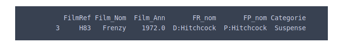

```python
# FILM PAR REALISATEUR - TABLE FILMS
```

```python
import pandas as pd
import numpy as np

FILMSCSV = pd.read_csv("/home/perrot/Bureau/TEST/FILMS.csv", encoding='utf8', sep=',')
FILMSCSV.columns = ('FilmRef', 'Film_Nom', 'Film_Ann', 'FR_nom', 'FP_nom', 'FS_nom', 'Process', 'Categorie', 'F_Rcp')
FILMS = FILMSCSV[['FilmRef', 'Film_Nom', 'Film_Ann', 'FR_nom', 'FP_nom', 'Categorie']]

SPR =  FILMS.query('FR_nom == "D:Hitchcock"')
print(SPR.head())
```

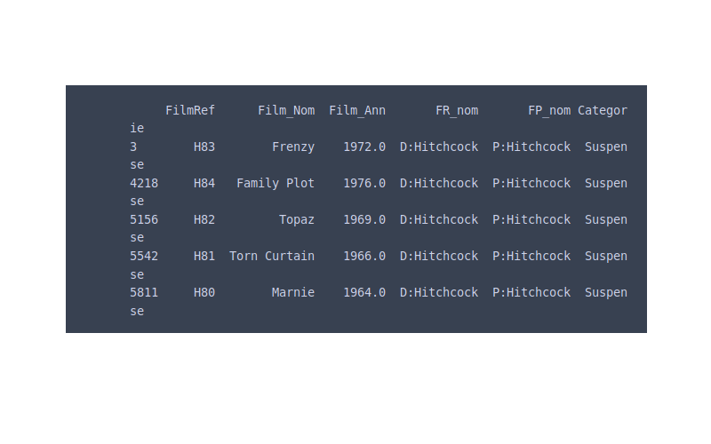

```python
# FILM PAR STUDIO - TABLE FILMS
```

```python
import pandas as pd
import numpy as np

FILMSCSV = pd.read_csv("/home/perrot/Bureau/TEST/FILMS.csv", encoding='utf8', sep=',')
FILMSCSV.columns = ('FilmRef', 'Film_Nom', 'Film_Ann', 'FR_nom', 'FP_nom', 'FS_nom', 'Process', 'Categorie', 'F_Rcp')
FILMS = FILMSCSV[['FilmRef', 'Film_Nom', 'Film_Ann', 'FS_nom', 'Categorie']]

SPS =  FILMS.query('FS_nom == "S:Disney"')
print(SPS.head())
```

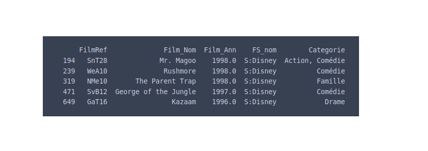

### Organiser les films par catégorie.

```python
#FILM PAR CATEGORIE - TABLE FILMS
```

```python
import pandas as pd
import numpy as np

FILMSCSV = pd.read_csv("/home/perrot/Bureau/TEST/FILMS.csv", encoding='utf8', sep=',')
FILMSCSV.columns = ('FilmRef', 'Film_Nom', 'Film_Ann', 'FR_nom', 'FP_nom', 'FS_nom', 'Process', 'Categorie', 'F_Rcp')
FILMS = FILMSCSV[['FilmRef', 'Film_Nom', 'Film_Ann', 'Categorie']]

SPCat =  FILMS.query('Categorie == "Action"')
print(SPCat.head())
```

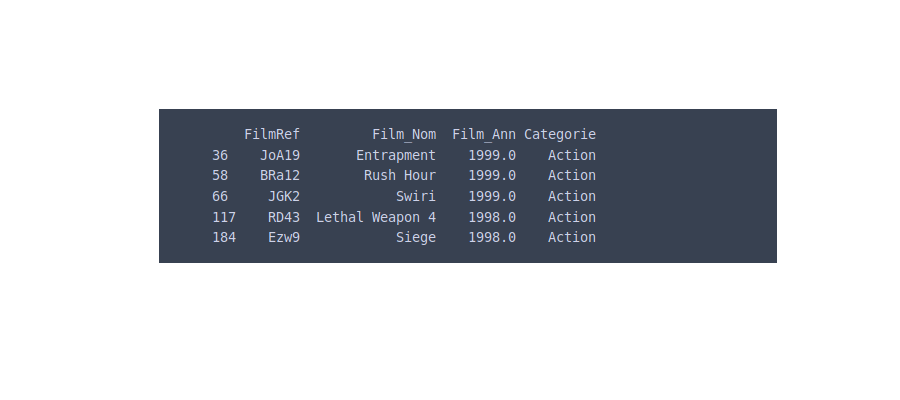

### Présenter des informations concernant les acteurs.

```python
#ACTEUR PAR DDN - TABLE ACTEURS
```

```python
import pandas as pd
import numpy as np

ACTEURSCSV = pd.read_csv("/home/perrot/Bureau/TEST/ACTEURS.csv", encoding = 'utf8', sep=',')
ACTEURSCSV.columns = ('ActeurID','Acteurs','Act_CDB','Act_CDF','Act_Prenoms','Act_Noms','Act_Sx','Act_DDN','Act_DDD','Act_Prf','Act_Orig')
ACTEURS = ACTEURSCSV[['ActeurID','Acteurs','Act_CDB','Act_CDF','Act_Prenoms','Act_Noms','Act_Sx','Act_DDN','Act_DDD','Act_Prf','Act_Orig']]

SAct =  ACTEURS.query('Acteurs == "Audrey Hepburn"')
print(SAct.head())
```

```python
#ACTEUR PAR FILM - TABLE CASTS
```

```python
# La fonction prend du temps à générer

import pandas as pd

CASTSCSV = pd.read_csv("/home/perrot/Bureau/TEST/GRAPHICCSV/CASTS.csv", encoding = 'utf8', sep=',')
CASTSCSV.columns = ('Film_Ref','Film_Nom','Acteurs','Pers','Role')
CASTS = CASTSCSV[['Film_Nom','Acteurs']]
#print(CASTS)

CASTS.groupby('Film_Nom')
print(CASTS.groupby('Film_Nom').groups)
gk = CASTS.groupby('Film_Nom')
gk.first()
grp = CASTS.groupby('Film_Nom')
for Film_Nom, group in grp:
    print(Film_Nom)
    print(group)
    print()
```

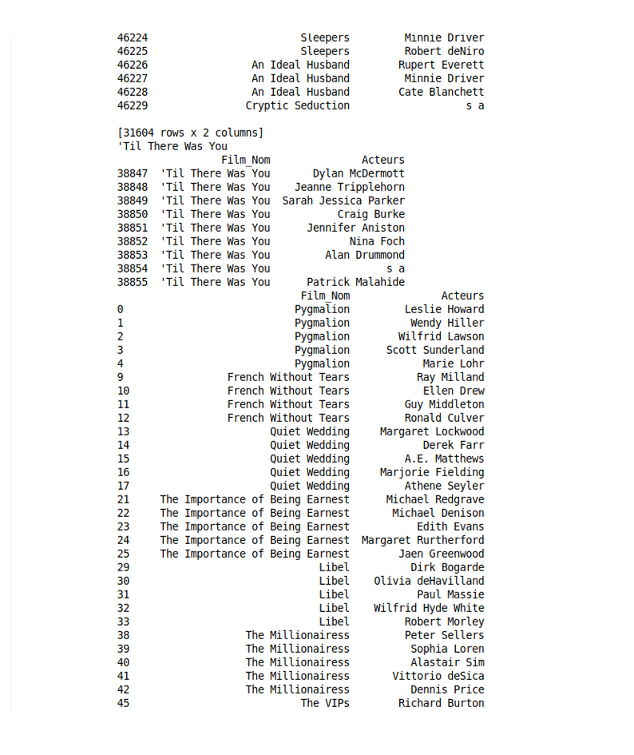

```python
import pandas as pd
import numpy as np

CASTSCSV = pd.read_csv("/home/perrot/Bureau/TEST/GRAPHICCSV/CASTS.csv", encoding = 'utf8', sep=',')
CASTSCSV.columns = ('Film_Ref','Film_Nom','Acteurs','Pers','Role')
CASTS = CASTSCSV[['Film_Nom','Acteurs']]
#print(CASTS)

SCAct =  CASTS.query('Film_Nom == "Sabrina"')
print(SCAct.head())
```

```python
#FILMS PAR ACTEUR - TABLE CASTS
```

```python
# Groupe par acteurs
#(attention: La fonction prend du temps à générer)

import pandas as pd

CASTSCSV = pd.read_csv("/home/perrot/Bureau/TEST/GRAPHICCSV/CASTS.csv", encoding = 'utf8', sep=',')
CASTSCSV.columns = ('Film_Ref','Film_Nom','Acteurs','Pers','Role')
CASTS = CASTSCSV[['Film_Nom','Acteurs']]
#print(CASTS)

CASTS.groupby('Acteurs')
print(CASTS.groupby('Acteurs').groups)
gk = CASTS.groupby('Acteurs')
gk.first()
grp = CASTS.groupby('Acteurs')
for Film_Nom, group in grp:
    print(Acteurs)
    print(group)
    print()
```

```python
# Groupe par une seule acteur

import pandas as pd
import numpy as np

CASTSCSV = pd.read_csv("/home/perrot/Bureau/TEST/GRAPHICCSV/CASTS.csv", encoding = 'utf8', sep=',')
CASTSCSV.columns = ('Film_Ref','Film_Nom','Acteurs','Pers','Role')
CASTS = CASTSCSV[['Film_Nom','Acteurs']]
#print(CASTS)

SCAct =  CASTS.query('Acteurs == "Audrey Hepburn"')
print(SCAct.head())
```

### Présenter des informations concernant les remake de films.

```python
#FILMS - REMAKE
```

```python
import pandas as pd

REMAKESCSV = pd.read_csv("/home/perrot/Bureau/TEST/REMAKES.csv", encoding='utf8', sep=',')
REMAKESCSV.columns = ('RemakeID', 'R_Film', 'R_Ann', 'RP', 'OrigID', 'O_Film', 'O_Ann')
REMAKES = REMAKESCSV[['OrigID', 'O_Film', 'O_Ann', 'RemakeID', 'R_Film', 'R_Ann']]

SFPR = REMAKES[(REMAKES.O_Film == "Pygmalion") | (REMAKES.R_Film == "")]
print(SFPR)
```

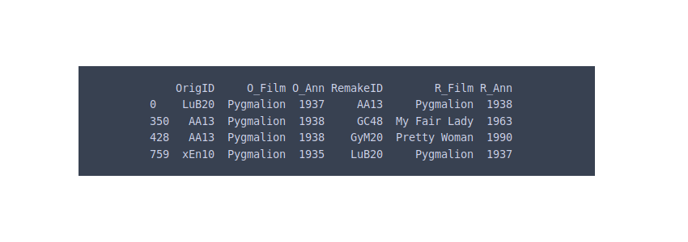

```python
#REMAKES - FILM
```

```python
import pandas as pd

REMAKESCSV = pd.read_csv("/home/perrot/Bureau/TEST/REMAKES.csv", encoding='utf8', sep=',')
REMAKESCSV.columns = ('RemakeID', 'R_Film', 'R_Ann', 'RP', 'OrigID', 'O_Film', 'O_Ann')
REMAKES = REMAKESCSV[['RemakeID', 'R_Film', 'R_Ann', 'OrigID', 'O_Film', 'O_Ann']]

SRPF = REMAKES[(REMAKES.R_Film == "Body Snatchers") | (REMAKES.O_Film == "")]
print(SRPF)
```

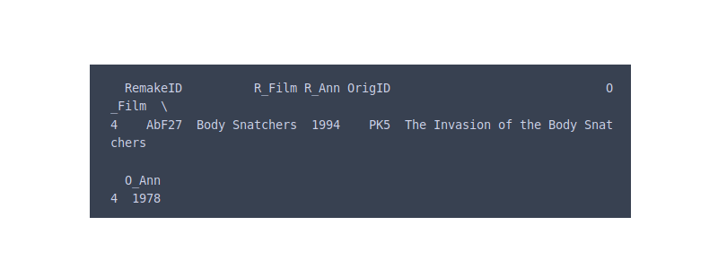

## Dataviz - possible dans l'API

### La nombre des Films par année de sortie

```python
"""
@author: perrot
"""
import pandas as pd
import seaborn as sns
import matplotlib.pyplot as plt


FILMSCSV = pd.read_csv("/home/perrot/Bureau/TEST/GRAPHICCSV/FILMS.csv", encoding = 'utf8', sep=',')
FILMSCSV.columns = ('FilmRef','Film_Nom', 'Film_Ann', 'FR_nom', 'FP_nom', 'FS_nom', 'Process', 'Categorie', 'F_Rcp')
FILMYR = FILMSCSV[['Film_Nom', 'Film_Ann','Categorie']]
FILMYR2 = FILMYR.dropna(axis = 0, how ='any')
#print(FILMYR2)

FILMYG = FILMYR2.groupby(['Film_Ann']).size().sort_values(ascending=False).reset_index()
FILMYG.columns = ["Film_Ann", "frequency"]

FILMYG_dff = FILMYG[(FILMYG["Film_Ann"] >= 1980)]

#ax = sns.pointplot(x="Film_Ann", y="frequency", data=FILMYG_dff, join=False, palette="Set2")

y = FILMYG_dff.groupby(['Film_Ann']).sum()
y = y['frequency']
x = y.index.astype(int)

plt.figure(figsize=(12,8))
ax = sns.barplot(y = y, x = x)
ax.set_xlabel(xlabel='Année de sortie', fontsize=16)
ax.set_xticklabels(labels = x, fontsize=12, rotation=50)
ax.set_ylabel(ylabel='Nombre', fontsize=16)
ax.set_title(label='La nombre des Films par année de sortie', fontsize=20)
plt.show();

fig = ax.get_figure()
fig.savefig('~/2.5.1_FilmAnnee.png')
```

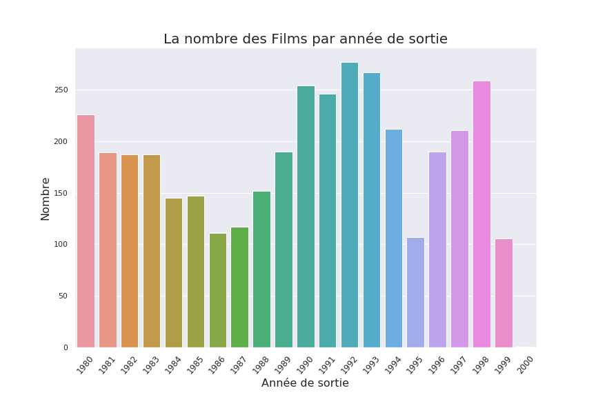

### Wordcloud par nombre d'occurrences de la Catégorie

```python
#Wordcloud par nombre d'occurrences de la Catégorie (plus d'occurrences = plus grand le mot)

"""
@author: perrot
"""

import pandas as pd
import plotly as plt
from wordcloud import WordCloud, STOPWORDS
from matplotlib import *
import sys
from pylab import *

FILMSCSV = pd.read_csv("/home/perrot/Bureau/TEST/GRAPHICCSV/FILMS.csv", encoding = 'utf8', sep=',')
FILMSCSV.columns = ('FilmRef','Film_Nom', 'Film_Ann', 'FR_nom', 'FP_nom', 'FS_nom', 'Process', 'Categorie', 'F_Rcp')
FILMCAT=FILMSCSV[['Film_Nom','Categorie']]

#FILMCY.columns = ["Categorie","Film_Ann"]
#FILMCAT["Categorie"] = FILMCY["Categorie"].apply(lambda x: x.strip())

words = dict()
trunc_occurences = FILMCAT.groupby(["Categorie"]).size().sort_values(ascending=False).reset_index()
trunc_occurences.columns = ["Categorie", "frequency"]
for i in range(18):
    words[trunc_occurences["Categorie"][i]] = trunc_occurences["frequency"][i]
tone = 179 # define the color of the words
f, ax = plt.subplots(figsize=(14, 6))
wordcloud = WordCloud(width=550,height=300, background_color='white',
                      max_words=162,relative_scaling=0.7,
                      normalize_plurals=False)
wordcloud.generate_from_frequencies(words)
plt.imshow(wordcloud, interpolation="bilinear")
plt.axis('off')
plt.show()

fig = ax.get_figure()
fig.savefig('~/2.5.2_Wordcloud.png')
```

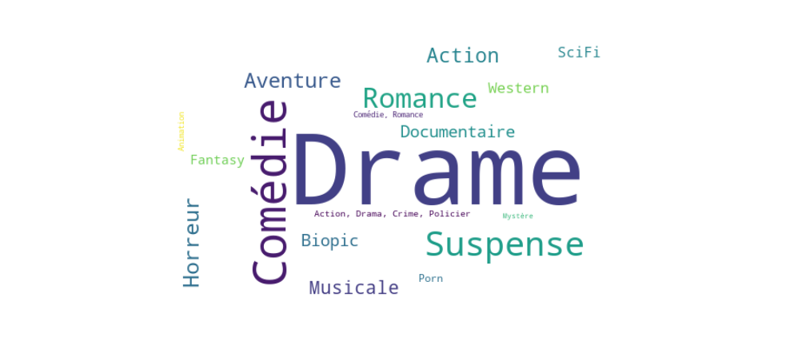

### Acteurs par temps de tournage

```python
"""
@author: marceline
"""
import pandas as pd
import matplotlib.pyplot as plt
import matplotlib.animation as animation
import numpy as np
import seaborn as sns


Acteurs=pd.read_csv("/home/perrot/Bureau/TEST/ACTEURS.csv", encoding = 'utf8', sep=',')
Acteurs.columns=['ActeurID','Acteurs','Act_CDB','Act_CDF','Act_Prenoms','Act_Noms','Act_Sx','Act_DDN','Act_DDD','Act_Prf','Act_Orig']
Acteurs2=Acteurs.dropna(axis = 0, how ='any')
ActeurTemp=Acteurs2[["Acteurs","Act_CDB", "Act_CDF"]]
ActeurMod=ActeurTemp.assign(Diff = ActeurTemp["Act_CDF"] - ActeurTemp["Act_CDB"])

dff = ActeurMod[(ActeurMod['Diff'] >65)]
ax = sns.pointplot(x="Diff", y="Acteurs", data=dff, color="#95a5a6", join=False )
ax.set_title(label='Acteurs par temps de tournage', fontsize=20)
plt.show();
```

[output not shown]

# l'API

## Plan d'API (voir 1.4.1.4)

## Code d'API (toujours en cours de conception)

```python
#!/usr/bin/env python3
# -- coding: utf-8 --
"""
Created on Mon Jul  1 16:17:27 2019

@author: rousseau
"""
import dash
import dash_auth
import dash_core_components as dcc
import dash_html_components as html
from dash.dependencies import Input, Output


# librairies dimport de données
import requests
from pandas.io.json import json_normalize

# librairies de manipulation des données
import pandas as pd


# librairies de visualisation (table + graph)
import dash_table
from dash_table import DataTable

VALID_USERNAME_PASSWORD_PAIRS = [
    ['hello', 'world']
]

app = dash.Dash('auth')
auth = dash_auth.BasicAuth(
    app,
    VALID_USERNAME_PASSWORD_PAIRS
)
# CREATION DE L'APPLICATION ----------------------------------------------------------------------------------------------------------
app = dash.Dash()

# Lecture du CSV par pandas, noter le format du fichier (local sur /home/goudot/movies/data)
#URL = "file:///home/rousseau/Bureau/TEST/FILMS.csv"
tbl = pd.read_csv("/home/perrot/Bureau/TEST/GRAPHICCSV/FILMS.csv", encoding = 'utf8', sep=',')
tbl.columns = ('FilmRef','Film_Nom', 'Film_Ann', 'FR_nom', 'FP_nom', 'FS_nom', 'Process', 'Categorie', 'F_Rcp')
    # le même, avec les colonnes qui nous intéresse
tbl1 = tbl[['Categorie']]
print(tbl.head())

# Extraction des villes disponibles dans la dataframe 'df'
print(tbl1.head())

Categorie_dispo = tbl1["Categorie"].unique()

colors = {
    'background': 'orange',
    'text': 'red'
}

app.layout = html.Div(style={'backgroundColor': colors['background']}, children=[
    # Titre de l'application ainsi qu'un peu d'habillage
    html.H1(
        children='Mediathéque',
        style={'textAlign': 'center', 'color': colors['text']}
    ),
    dcc.Input(id='my-id', value='Dash App', type='text'),
    html.Div(id='my-div'),


#
#    html.Br(),
#   html.Hr(),
#    html.Label('Choix Categorie', style={'fontSize': 20, 'marginTop': 30,'color': colors['text']}),
#    dcc.Checklist(
#        id='input-Categorie',
#        # Pour les valeurs de Categorie, intégration dynamique de la variable 'Categorie_dispo' déclarée en amont et issue de la dataframe 'df'
#        options=[{'label': i, 'value': i} for i in Categorie_dispo],
#        values=Categorie_dispo
#    ),
    html.Br(),
    html.Br(),
    html.Div(id='output-Categorie'),



    html.H4('Sélectionner votre catégorie'),
    dcc.Dropdown(
    options=[
        {'label': 'Suspense', 'value': 'Susp'},
        {'label': 'Dramatique', 'value': 'Dram'},
        {'label': 'Comédie', 'value': 'Comd'},
        {'label': 'Romantique', 'value': 'Romt'},
        {'label': 'Science-fiction', 'value': 'ScFi'},
        {'label': 'Action', 'value': 'Actn'},
        {'label': 'Horreur', 'value': 'Horr'},
        {'label': 'Pornographique', 'value': 'Porn'},
        {'label': 'Déssin-animé', 'value': 'Cart'}
    ],
    value='MTL'
),


    dcc.Slider(
        id='my-slider',
        min=1900,
        max=2019,
        step=1,
        value=10,
    ),
    html.Div(id='slider-output-container'),

     html.H3(
        children="Développé par Marceline, Sondra et Franck",
        style={'textAlign': 'center', 'color': colors['text']}
        ),
])


@app.callback(
    dash.dependencies.Output('slider-output-container', 'children'),
    [dash.dependencies.Input('my-slider', 'value')])
def update_output(value):
    return 'Sélection par année"{}"'.format(value)




#@app.callback(Output(component_id='output-Categorie', component_property='children'),
#              [Input(component_id='input-Categorie', component_property='values')])
def update_output_div(input_value):
   # return tlb

    print(tbl1.head())


Categorie_dispo = tbl1["Categorie"].unique()



if __name__ == '__main__':
#    app.run_server()
    # app.run_server(debug=False, port=8080)
```

[figure not shown]

```python
import dash
import dash_core_components as dcc
import dash_html_components as html
import pandas as pd

df = pd.read_csv('/home/perrot/Bureau/TEST/GRAPHICCSV/FILMS.csv')


def generate_table(dataframe, max_rows=10):
    return html.Table(
        # Header
        [html.Tr([html.Th(col) for col in dataframe.columns])] +

        # Body
        [html.Tr([
            html.Td(dataframe.iloc[i][col]) for col in dataframe.columns
        ]) for i in range(min(len(dataframe), max_rows))]
    )


external_stylesheets = ['https://codepen.io/chriddyp/pen/bWLwgP.css']

app = dash.Dash(__name__, external_stylesheets=external_stylesheets)

app.layout = html.Div(children=[
    html.H4(children='Film'),
    generate_table(df)
])

if __name__ == '__main__':
#    app.run_server(debug=True)
```

[figure not shown]

# Conclusion

## de Projet

```python
 - Notre representations MCP MDP a changez
 - Les données avait plusiers limitations
```

## Perspectives personnelles